# Aula 5 - Análise de Dados de Contagem: Da ANOVA ao GLM

## 1. Introdução e Análise Exploratória

Nesta análise, vamos investigar a eficácia de diferentes inseticidas (`spray`) na contagem de insetos sobreviventes (`count`). Este é um exemplo clássico de dados de contagem (números inteiros não negativos).

Primeiro, carregamos os pacotes necessários e realizamos uma análise visual exploratória para entender a distribuição e a variabilidade dos dados.

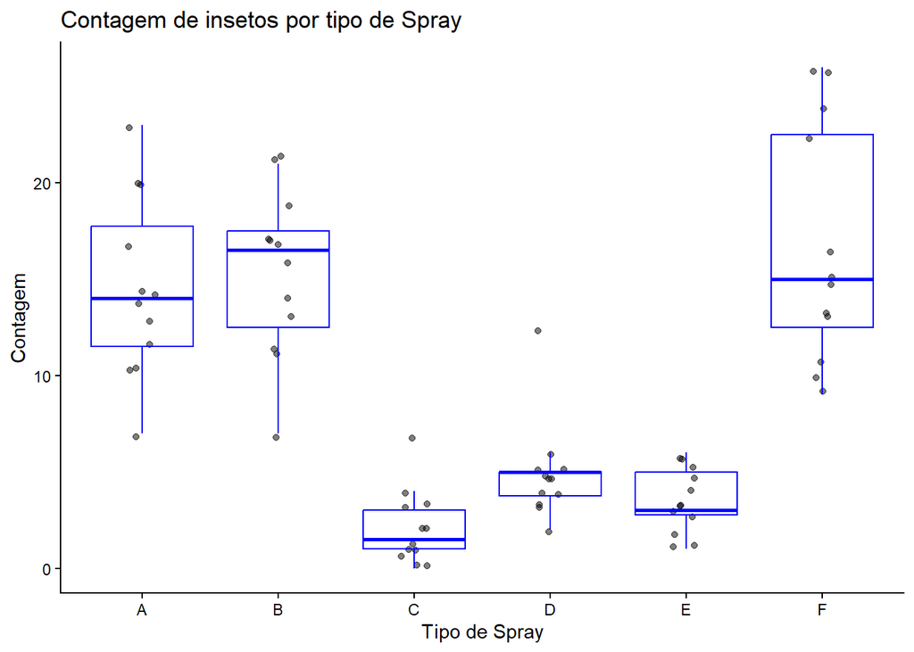

```r
# Carregar dados nativos do R
insects <- InsectSprays

# Carregar pacotes
library(ggplot2)
library(tidyverse)
# Análise visual exploratória
# Combinamos jitter (para ver cada ponto individualmente sem sobreposição)
# e boxplot (para visualizar medianas e quartis).
insects |> ggplot(aes(x = spray, y = count)) +
  geom_jitter(width = 0.1, alpha = 0.5) +
  geom_boxplot(outlier.colour = NA, fill = NA, color = "blue") +
  theme_classic() +
  labs(title = "Contagem de insetos por tipo de Spray",
       x = "Tipo de Spray",
       y = "Contagem")
```

## 2. Modelo Linear Tradicional (ANOVA) e Pressupostos

A abordagem mais comum (e muitas vezes inicial) é ajustar um modelo linear clássico (ANOVA). O modelo linear ($Y = \beta_0 + \beta_1X + \epsilon$) assume que os resíduos ($\epsilon$) têm: 1. **Normalidade:** Seguem uma distribuição Gaussiana. 2. **Homocedasticidade:** Possuem variância constante entre os tratamentos.

Vamos ajustar o modelo e testar essas suposições matematicamente e visualmente.

```r
# Ajuste do modelo linear
m1 <- lm(count ~ spray, data = insects)

# Resumo do modelo e quadro da ANOVA
summary(m1)
```

```
Call:
lm(formula = count ~ spray, data = insects)

Residuals:
   Min     1Q Median     3Q    Max
-8.333 -1.958 -0.500  1.667  9.333

Coefficients:
            Estimate Std. Error t value Pr(>|t|)
(Intercept)  14.5000     1.1322  12.807  < 2e-16 ***
sprayB        0.8333     1.6011   0.520    0.604
sprayC      -12.4167     1.6011  -7.755 7.27e-11 ***
sprayD       -9.5833     1.6011  -5.985 9.82e-08 ***
sprayE      -11.0000     1.6011  -6.870 2.75e-09 ***
sprayF        2.1667     1.6011   1.353    0.181
---
Signif. codes:  0 '***' 0.001 '**' 0.01 '*' 0.05 '.' 0.1 ' ' 1

Residual standard error: 3.922 on 66 degrees of freedom
Multiple R-squared:  0.7244,    Adjusted R-squared:  0.7036
F-statistic:  34.7 on 5 and 66 DF,  p-value: < 2.2e-16
```

```r
anova(m1)
```

|  | Df | Sum Sq | Mean Sq | F value | Pr(>F) |
| --- | --- | --- | --- | --- | --- |
| spray | 5 | 2668.833 | 533.76667 | 34.70228 | 3.182584e-17 |
| Residuals | 66 | 1015.167 | 15.38131 | NA | NA |

### 2.1. Checagem de Pressupostos

```r
# Testes Estatísticos Clássicos
# H0 do Shapiro: Os dados vêm de uma distribuição Normal.
shapiro.test(m1$residuals)
```

```
    Shapiro-Wilk normality test

data:  m1$residuals
W = 0.96006, p-value = 0.02226
```

```r
# p-value 0.02 (<0.05) rejeita H0, ou seja, NÃO-NORMAL.

# H0 do Bartlett: As variâncias são homogêneas (iguais) entre os grupos.
bartlett.test(count ~ spray, data = insects)
```

```
    Bartlett test of homogeneity of variances

data:  count by spray
Bartlett's K-squared = 25.96, df = 5, p-value = 9.085e-05
```

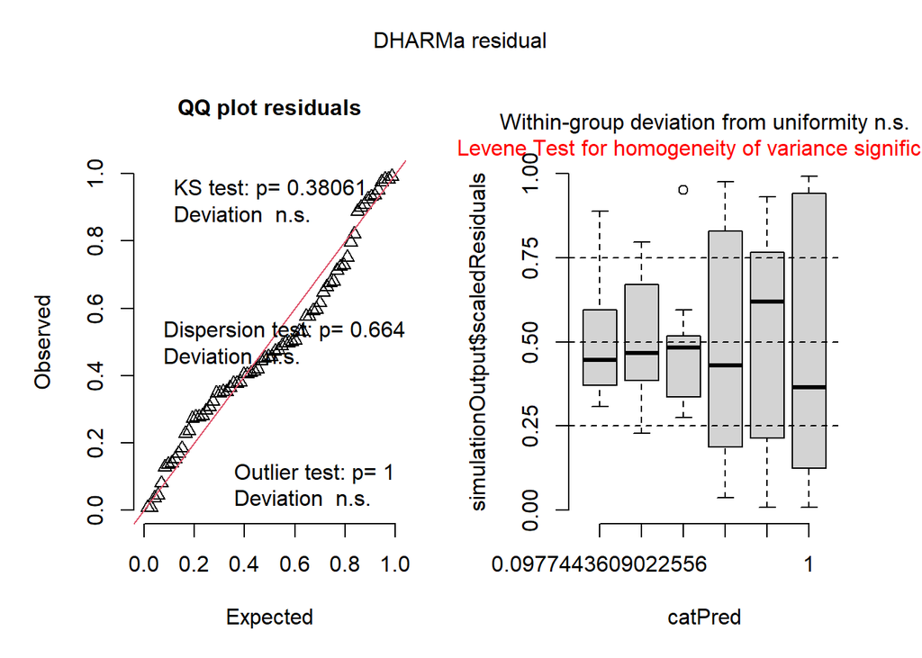

```r
# p-valor baixo, rejeita H0, NÃO-HOMOGÊNEO.

# Pacote performance para checagem rápida
library(performance)
check_normality(m1) # Confirma falta de normalidade.
check_heteroscedasticity(m1) # Confirma falta de homocedasticidade (heterocedástico).
# Pacote DHARMa para resíduos simulados (excelente padrão ouro moderno)
library(DHARMa)
plot(simulateResiduals(m1)) # O gráfico aponta desvios graves, especialmente na variância.
```

**Conclusão da Etapa 2:** Os dados violam gravemente os pressupostos da ANOVA. Isso ocorre porque dados de contagem têm um limite inferior (zero) e a variância costuma crescer junto com a média. Precisamos de outras abordagens.

## 3. Alternativa 1: Transformação de Dados

Uma técnica clássica para lidar com dados de contagem heterocedásticos é aplicar a **Transformação de Raiz Quadrada** ($\sqrt{Y}$). Ela “comprime” os valores muito altos, estabilizando a variância.

```r
# Criando a variável transformada (opcional se for feita direto no lm, mas bom para visualizar)
insects2 <- insects |>
  mutate(count2 = sqrt(count))

# Ajustando novo modelo com a variável resposta dentro da raiz quadrada
m2 <- lm(sqrt(count) ~ spray, data = insects)

# Checando os pressupostos no novo modelo
shapiro.test(m2$residuals) # Não rejeita H0 (Agora é NORMAL)
```

```
    Shapiro-Wilk normality test

data:  m2$residuals
W = 0.98721, p-value = 0.6814
```

```r
bartlett.test(sqrt(count) ~ spray, data = insects) # Não rejeita H0 (Agora é HOMOGÊNEO)
```

```
    Bartlett test of homogeneity of variances

data:  sqrt(count) by spray
Bartlett's K-squared = 3.7525, df = 5, p-value = 0.5856
```

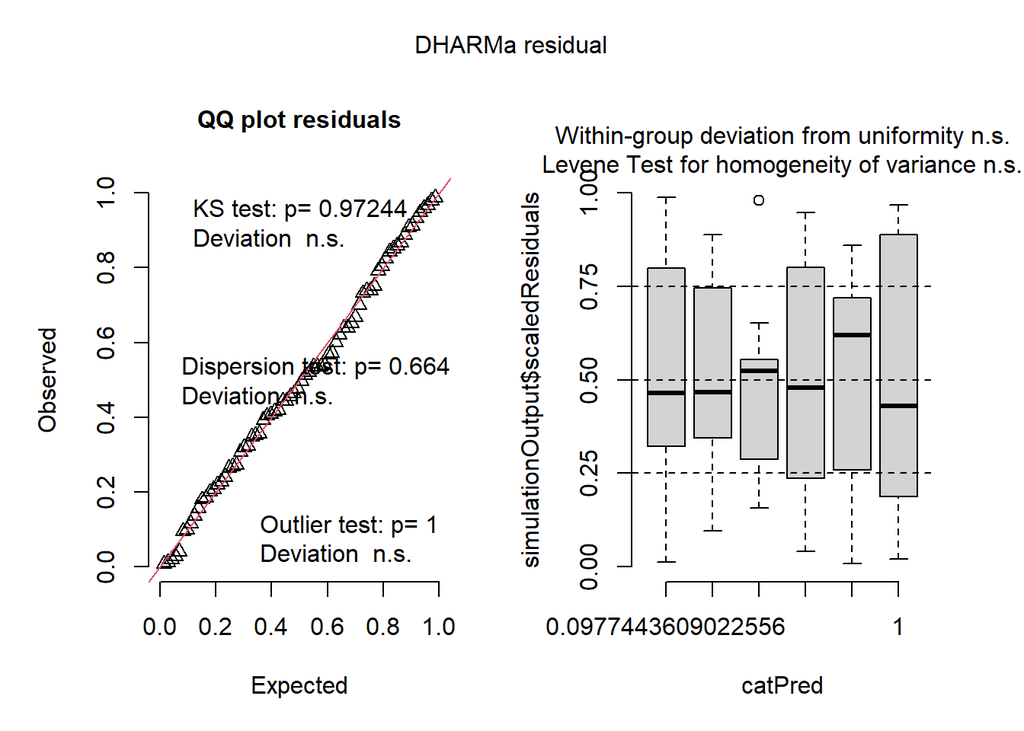

```r
# Visualização da transformação (DHARMa)
plot(simulateResiduals(m2)) # Sem avisos em vermelho agora! Os resíduos estão bem comportados
```

### 3.1. Comparações Múltiplas e Destransformação

Como ajustamos o modelo com `sqrt(count)` no R, o pacote `emmeans` reconhece automaticamente a transformação. Ao pedir `type = "response"`, ele eleva as médias ao quadrado para devolver os resultados na escala original.

```r
library(emmeans)
library(multcomp)
# Médias do modelo violado (Apenas para comparação pedagógica)
medias <- emmeans(m1, ~spray)

# Médias do modelo corrigido, na escala original destransformada
medias2 <- emmeans(m2, ~spray, type = "response")

# Comparações Múltiplas
cld(medias) # Agrupamento do modelo com pressupostos violados
```

|  | spray | emmean | SE | df | lower.CL | upper.CL | .group |
| --- | --- | --- | --- | --- | --- | --- | --- |
| 3 | C | 2.083333 | 1.132156 | 66 | -0.1770881 | 4.343755 | 1 |
| 5 | E | 3.500000 | 1.132156 | 66 | 1.2395786 | 5.760421 | 1 |
| 4 | D | 4.916667 | 1.132156 | 66 | 2.6562453 | 7.177088 | 1 |
| 1 | A | 14.500000 | 1.132156 | 66 | 12.2395786 | 16.760421 | 2 |
| 2 | B | 15.333333 | 1.132156 | 66 | 13.0729119 | 17.593755 | 2 |
| 6 | F | 16.666667 | 1.132156 | 66 | 14.4062453 | 18.927088 | 2 |

```r
cld(medias2) # Agrupamento do modelo matematicamente correto
```

|  | spray | response | SE | df | lower.CL | upper.CL | .group |
| --- | --- | --- | --- | --- | --- | --- | --- |
| 3 | C | 1.549668 | 0.4516033 | 66 | 0.7791672 | 2.582477 | 1 |
| 5 | E | 3.274149 | 0.6564278 | 66 | 2.0947029 | 4.715904 | 12 |
| 4 | D | 4.684428 | 0.7851742 | 66 | 3.2479310 | 6.383233 | 2 |
| 1 | A | 14.142702 | 1.3642814 | 66 | 11.5499805 | 16.997732 | 3 |
| 2 | B | 15.028271 | 1.4063463 | 66 | 12.3515643 | 17.967286 | 3 |
| 6 | F | 16.149284 | 1.4578552 | 66 | 13.3697363 | 19.191140 | 3 |

```r
# Nota: Destransformou os valores. O valor final aproxima-se da média aritmética,
# mas não é igual devido ao efeito não-linear da raiz.
# Note que houve uma ligeira diferença no agrupamento de tratamentos por significância (as letras mudaram).
```

## 4. Alternativa 2: Estatística Não-Paramétrica

Se não quisermos transformar dados, podemos usar testes não-paramétricos (baseados em postos/ranks) que não exigem normalidade, como o **Kruskal-Wallis**.

```r
library(agricolae)

# Teste de Kruskal-Wallis
k <- kruskal(insects$count, insects$spray)
k
```

```
$statistics
     Chisq Df      p.chisq  t.value      MSD
  54.69134  5 1.510845e-10 1.996564 8.462804

$parameters
            test p.ajusted        name.t ntr alpha
  Kruskal-Wallis      none insects$spray   6  0.05

$means
  insects.count     rank      std  r Min Max   Q25  Q50   Q75
A     14.500000 52.16667 4.719399 12   7  23 11.50 14.0 17.75
B     15.333333 54.83333 4.271115 12   7  21 12.50 16.5 17.50
C      2.083333 11.45833 1.975225 12   0   7  1.00  1.5  3.00
D      4.916667 25.58333 2.503028 12   2  12  3.75  5.0  5.00
E      3.500000 19.33333 1.732051 12   1   6  2.75  3.0  5.00
F     16.666667 55.62500 6.213378 12   9  26 12.50 15.0 22.50

$comparison
NULL

$groups
  insects$count groups
F      55.62500      a
B      54.83333      a
A      52.16667      a
D      25.58333      b
E      19.33333     bc
C      11.45833      c

attr(,"class")
[1] "group"
```

```r
# O agrupamento obtido aqui foi idêntico ao dos dados transformados com raiz quadrada.
```